# Risk Factor Analysis

## Outcome Variable

**Outcome Variable:** whz

## Predictor Variables

**Intervention Variable:** parity

**Adjustment Set:**

- arm
- W_mage
- meducyrs
- feducyrs
- hhwealth_quart
- W_mhtcm
- W_mwtkg
- W_mbmi
- vagbrth
- W_nrooms
- impsan
- delta_W_mage
- delta_meducyrs
- delta_feducyrs
- delta_hhwealth_quart
- delta_W_mhtcm
- delta_W_mwtkg
- delta_W_mbmi
- delta_vagbrth
- delta_W_nrooms
- delta_impsan

## Stratifying Variables

The analysis was stratified on these variable(s):

- agecat
- studyid
- country

## Data Summary

| agecat | studyid | country | parity | n_cell | n |
| --- | --- | --- | --- | --- | --- |
| Birth | ki1000304b-SAS-CompFeed | INDIA | 1 | 304 | 1103 |
| Birth | ki1000304b-SAS-CompFeed | INDIA | 2 | 258 | 1103 |
| Birth | ki1000304b-SAS-CompFeed | INDIA | 3+ | 541 | 1103 |
| Birth | ki1017093b-PROVIDE | BANGLADESH | 1 | 202 | 532 |
| Birth | ki1017093b-PROVIDE | BANGLADESH | 2 | 182 | 532 |
| Birth | ki1017093b-PROVIDE | BANGLADESH | 3+ | 148 | 532 |
| Birth | ki1101329-Keneba | GAMBIA | 1 | 146 | 1338 |
| Birth | ki1101329-Keneba | GAMBIA | 2 | 142 | 1338 |
| Birth | ki1101329-Keneba | GAMBIA | 3+ | 1050 | 1338 |
| Birth | ki1113344-GMS-Nepal | NEPAL | 1 | 185 | 641 |
| Birth | ki1113344-GMS-Nepal | NEPAL | 2 | 169 | 641 |
| Birth | ki1113344-GMS-Nepal | NEPAL | 3+ | 287 | 641 |
| Birth | ki1126311-ZVITAMBO | ZIMBABWE | 1 | 5561 | 12916 |
| Birth | ki1126311-ZVITAMBO | ZIMBABWE | 2 | 3882 | 12916 |
| Birth | ki1126311-ZVITAMBO | ZIMBABWE | 3+ | 3473 | 12916 |
| Birth | ki1135781-COHORTS | GUATEMALA | 1 | 94 | 756 |
| Birth | ki1135781-COHORTS | GUATEMALA | 2 | 118 | 756 |
| Birth | ki1135781-COHORTS | GUATEMALA | 3+ | 544 | 756 |
| Birth | ki1135781-COHORTS | INDIA | 1 | 641 | 3855 |
| Birth | ki1135781-COHORTS | INDIA | 2 | 982 | 3855 |
| Birth | ki1135781-COHORTS | INDIA | 3+ | 2232 | 3855 |
| Birth | ki1135781-COHORTS | PHILIPPINES | 1 | 640 | 2899 |
| Birth | ki1135781-COHORTS | PHILIPPINES | 2 | 657 | 2899 |
| Birth | ki1135781-COHORTS | PHILIPPINES | 3+ | 1602 | 2899 |
| Birth | kiGH5241-JiVitA-3 | BANGLADESH | 1 | 5520 | 18014 |
| Birth | kiGH5241-JiVitA-3 | BANGLADESH | 2 | 6303 | 18014 |
| Birth | kiGH5241-JiVitA-3 | BANGLADESH | 3+ | 6191 | 18014 |
| 6 months | ki1000304b-SAS-CompFeed | INDIA | 1 | 392 | 1334 |
| 6 months | ki1000304b-SAS-CompFeed | INDIA | 2 | 302 | 1334 |
| 6 months | ki1000304b-SAS-CompFeed | INDIA | 3+ | 640 | 1334 |

[output cut: 57 more lines]

The following strata were considered:

- agecat: 24 months, studyid: ki1017093b-PROVIDE, country: BANGLADESH
- agecat: 24 months, studyid: ki1066203-TanzaniaChild2, country: TANZANIA, UNITED REPUBLIC OF
- agecat: 24 months, studyid: ki1101329-Keneba, country: GAMBIA
- agecat: 24 months, studyid: ki1113344-GMS-Nepal, country: NEPAL
- agecat: 24 months, studyid: ki1126311-ZVITAMBO, country: ZIMBABWE
- agecat: 24 months, studyid: ki1135781-COHORTS, country: GUATEMALA
- agecat: 24 months, studyid: ki1135781-COHORTS, country: INDIA
- agecat: 24 months, studyid: ki1135781-COHORTS, country: PHILIPPINES
- agecat: 24 months, studyid: kiGH5241-JiVitA-3, country: BANGLADESH
- agecat: 6 months, studyid: ki1000304b-SAS-CompFeed, country: INDIA
- agecat: 6 months, studyid: ki1000304b-SAS-FoodSuppl, country: INDIA
- agecat: 6 months, studyid: ki1017093b-PROVIDE, country: BANGLADESH
- agecat: 6 months, studyid: ki1066203-TanzaniaChild2, country: TANZANIA, UNITED REPUBLIC OF
- agecat: 6 months, studyid: ki1101329-Keneba, country: GAMBIA
- agecat: 6 months, studyid: ki1113344-GMS-Nepal, country: NEPAL
- agecat: 6 months, studyid: ki1126311-ZVITAMBO, country: ZIMBABWE
- agecat: 6 months, studyid: ki1135781-COHORTS, country: GUATEMALA
- agecat: 6 months, studyid: ki1135781-COHORTS, country: INDIA
- agecat: 6 months, studyid: ki1135781-COHORTS, country: PHILIPPINES
- agecat: 6 months, studyid: kiGH5241-JiVitA-3, country: BANGLADESH
- agecat: Birth, studyid: ki1000304b-SAS-CompFeed, country: INDIA
- agecat: Birth, studyid: ki1017093b-PROVIDE, country: BANGLADESH
- agecat: Birth, studyid: ki1101329-Keneba, country: GAMBIA
- agecat: Birth, studyid: ki1113344-GMS-Nepal, country: NEPAL
- agecat: Birth, studyid: ki1126311-ZVITAMBO, country: ZIMBABWE
- agecat: Birth, studyid: ki1135781-COHORTS, country: GUATEMALA
- agecat: Birth, studyid: ki1135781-COHORTS, country: INDIA
- agecat: Birth, studyid: ki1135781-COHORTS, country: PHILIPPINES
- agecat: Birth, studyid: kiGH5241-JiVitA-3, country: BANGLADESH

### Dropped Strata

Some strata were dropped due to rare outcomes:

- agecat: 24 months, studyid: ki1066203-TanzaniaChild2, country: TANZANIA, UNITED REPUBLIC OF

## Methods Detail

We’re interested in the causal parameters $E[Y_a]$ for all values of $a \in \mathcal{A}$. These parameters represent the mean outcome if, possibly contrary to fact, we intervened to set all units to have $A=a$. Under the randomization and positivity assumptions, these are identified by the statistical parameters $\psi_a=E_W[E_{Y|A,W}(Y|A=a,W)]$. In addition, we’re interested in the mean of $Y$, $E[Y]$ under no intervention (the observed mean). We will estimate these parameters by using SuperLearner to fit the relevant likelihood factors – $E_{Y|A,W}(Y|A=a,W)$ and $p(A=a|W)$, and then updating our likelihood fit using a joint TMLE.

For unadjusted analyses ($W=\{\}$), initial likelihoods were estimated using Lrnr_glm to estimate the simple $E(Y|A)$ and Lrnr_mean to estimate $p(A)$. For adjusted analyses, a small library containing Lrnr_glmnet, Lrnr_xgboost, and Lrnr_mean was used.

Having estimated these parameters, we will then use the delta method to estimate relative risks and attributable risks relative to a prespecified baseline level of $A$.

# Results Detail

## Results Plots

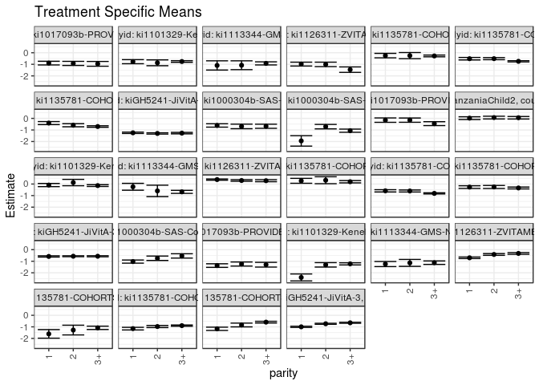

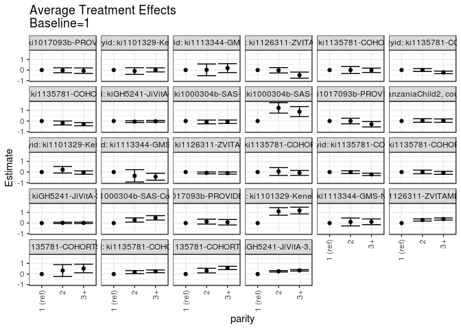

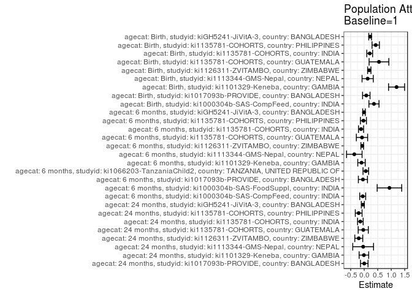

## Results Table

### Parameter: TSM

| agecat | studyid | country | intervention_level | baseline_level | estimate | ci_lower | ci_upper |
| --- | --- | --- | --- | --- | --- | --- | --- |
| Birth | ki1000304b-SAS-CompFeed | INDIA | 1 | NA | -1.0304662 | -1.1664017 | -0.8945307 |
| Birth | ki1000304b-SAS-CompFeed | INDIA | 2 | NA | -0.7429214 | -0.9341577 | -0.5516851 |
| Birth | ki1000304b-SAS-CompFeed | INDIA | 3+ | NA | -0.5406136 | -0.7288012 | -0.3524261 |
| Birth | ki1017093b-PROVIDE | BANGLADESH | 1 | NA | -1.3755060 | -1.5298428 | -1.2211693 |
| Birth | ki1017093b-PROVIDE | BANGLADESH | 2 | NA | -1.2413965 | -1.4162774 | -1.0665156 |
| Birth | ki1017093b-PROVIDE | BANGLADESH | 3+ | NA | -1.3008482 | -1.5034371 | -1.0982594 |
| Birth | ki1101329-Keneba | GAMBIA | 1 | NA | -2.4015693 | -2.7024149 | -2.1007236 |
| Birth | ki1101329-Keneba | GAMBIA | 2 | NA | -1.3114447 | -1.5025277 | -1.1203617 |
| Birth | ki1101329-Keneba | GAMBIA | 3+ | NA | -1.2274001 | -1.3190931 | -1.1357071 |
| Birth | ki1113344-GMS-Nepal | NEPAL | 1 | NA | -1.2444161 | -1.4640429 | -1.0247893 |
| Birth | ki1113344-GMS-Nepal | NEPAL | 2 | NA | -1.1438796 | -1.4429052 | -0.8448540 |
| Birth | ki1113344-GMS-Nepal | NEPAL | 3+ | NA | -1.1259591 | -1.2762746 | -0.9756436 |
| Birth | ki1126311-ZVITAMBO | ZIMBABWE | 1 | NA | -0.7028731 | -0.7697676 | -0.6359785 |
| Birth | ki1126311-ZVITAMBO | ZIMBABWE | 2 | NA | -0.4141790 | -0.4905553 | -0.3378027 |
| Birth | ki1126311-ZVITAMBO | ZIMBABWE | 3+ | NA | -0.3251998 | -0.3989393 | -0.2514604 |
| Birth | ki1135781-COHORTS | GUATEMALA | 1 | NA | -1.6084053 | -1.9796435 | -1.2371672 |
| Birth | ki1135781-COHORTS | GUATEMALA | 2 | NA | -1.2763506 | -1.6966222 | -0.8560790 |
| Birth | ki1135781-COHORTS | GUATEMALA | 3+ | NA | -1.0826114 | -1.2279681 | -0.9372548 |
| Birth | ki1135781-COHORTS | INDIA | 1 | NA | -1.1532132 | -1.2664847 | -1.0399418 |
| Birth | ki1135781-COHORTS | INDIA | 2 | NA | -0.9706626 | -1.0611973 | -0.8801278 |
| Birth | ki1135781-COHORTS | INDIA | 3+ | NA | -0.8937536 | -0.9475497 | -0.8399574 |
| Birth | ki1135781-COHORTS | PHILIPPINES | 1 | NA | -1.1684163 | -1.3098250 | -1.0270076 |
| Birth | ki1135781-COHORTS | PHILIPPINES | 2 | NA | -0.8375966 | -1.0004011 | -0.6747921 |
| Birth | ki1135781-COHORTS | PHILIPPINES | 3+ | NA | -0.5909535 | -0.6635902 | -0.5183169 |
| Birth | kiGH5241-JiVitA-3 | BANGLADESH | 1 | NA | -0.9968464 | -1.0499689 | -0.9437239 |
| Birth | kiGH5241-JiVitA-3 | BANGLADESH | 2 | NA | -0.7321691 | -0.7740653 | -0.6902729 |
| Birth | kiGH5241-JiVitA-3 | BANGLADESH | 3+ | NA | -0.6493609 | -0.6903883 | -0.6083334 |
| 6 months | ki1000304b-SAS-CompFeed | INDIA | 1 | NA | -0.6096059 | -0.7550978 | -0.4641140 |
| 6 months | ki1000304b-SAS-CompFeed | INDIA | 2 | NA | -0.6953372 | -0.8929263 | -0.4977482 |
| 6 months | ki1000304b-SAS-CompFeed | INDIA | 3+ | NA | -0.6804155 | -0.8579299 | -0.5029011 |

[output cut: 54 more lines]

### Parameter: E(Y)

| agecat | studyid | country | intervention_level | baseline_level | estimate | ci_lower | ci_upper |
| --- | --- | --- | --- | --- | --- | --- | --- |
| Birth | ki1000304b-SAS-CompFeed | INDIA | NA | NA | -0.6700453 | -0.8474950 | -0.4925957 |
| Birth | ki1017093b-PROVIDE | BANGLADESH | NA | NA | -1.2984586 | -1.3752758 | -1.2216415 |
| Birth | ki1101329-Keneba | GAMBIA | NA | NA | -1.2037220 | -1.2694226 | -1.1380213 |
| Birth | ki1113344-GMS-Nepal | NEPAL | NA | NA | -1.1164431 | -1.2040134 | -1.0288728 |
| Birth | ki1126311-ZVITAMBO | ZIMBABWE | NA | NA | -0.5156349 | -0.5414936 | -0.4897762 |
| Birth | ki1135781-COHORTS | GUATEMALA | NA | NA | -1.0621429 | -1.1631387 | -0.9611471 |
| Birth | ki1135781-COHORTS | INDIA | NA | NA | -0.9498080 | -0.9874148 | -0.9122013 |
| Birth | ki1135781-COHORTS | PHILIPPINES | NA | NA | -0.7427251 | -0.7890855 | -0.6963647 |
| Birth | kiGH5241-JiVitA-3 | BANGLADESH | NA | NA | -0.7778272 | -0.7968313 | -0.7588232 |
| 6 months | ki1000304b-SAS-CompFeed | INDIA | NA | NA | -0.6657084 | -0.8024377 | -0.5289791 |
| 6 months | ki1000304b-SAS-FoodSuppl | INDIA | NA | NA | -1.0121579 | -1.1280429 | -0.8962729 |
| 6 months | ki1017093b-PROVIDE | BANGLADESH | NA | NA | -0.1990907 | -0.2817968 | -0.1163845 |
| 6 months | ki1066203-TanzaniaChild2 | TANZANIA, UNITED REPUBLIC OF | NA | NA | 0.0797179 | 0.0266621 | 0.1327737 |
| 6 months | ki1101329-Keneba | GAMBIA | NA | NA | -0.1873900 | -0.2456638 | -0.1291162 |
| 6 months | ki1113344-GMS-Nepal | NEPAL | NA | NA | -0.6038416 | -0.6899448 | -0.5177384 |
| 6 months | ki1126311-ZVITAMBO | ZIMBABWE | NA | NA | 0.3106432 | 0.2849661 | 0.3363203 |
| 6 months | ki1135781-COHORTS | GUATEMALA | NA | NA | 0.1940810 | 0.1226351 | 0.2655269 |
| 6 months | ki1135781-COHORTS | INDIA | NA | NA | -0.7068611 | -0.7417800 | -0.6719423 |
| 6 months | ki1135781-COHORTS | PHILIPPINES | NA | NA | -0.2938433 | -0.3352064 | -0.2524802 |
| 6 months | kiGH5241-JiVitA-3 | BANGLADESH | NA | NA | -0.5935161 | -0.6130518 | -0.5739805 |
| 24 months | ki1017093b-PROVIDE | BANGLADESH | NA | NA | -0.8928670 | -0.9755153 | -0.8102187 |
| 24 months | ki1101329-Keneba | GAMBIA | NA | NA | -0.7834078 | -0.8357743 | -0.7310414 |
| 24 months | ki1113344-GMS-Nepal | NEPAL | NA | NA | -1.1363107 | -1.2252817 | -1.0473398 |
| 24 months | ki1126311-ZVITAMBO | ZIMBABWE | NA | NA | -1.1817824 | -1.2809226 | -1.0826422 |
| 24 months | ki1135781-COHORTS | GUATEMALA | NA | NA | -0.2813755 | -0.3354674 | -0.2272835 |
| 24 months | ki1135781-COHORTS | INDIA | NA | NA | -0.6564729 | -0.6914450 | -0.6215007 |
| 24 months | ki1135781-COHORTS | PHILIPPINES | NA | NA | -0.6099592 | -0.6467541 | -0.5731643 |
| 24 months | kiGH5241-JiVitA-3 | BANGLADESH | NA | NA | -1.2978031 | -1.3210763 | -1.2745298 |

### Parameter: ATE

| agecat | studyid | country | intervention_level | baseline_level | estimate | ci_lower | ci_upper |
| --- | --- | --- | --- | --- | --- | --- | --- |
| Birth | ki1000304b-SAS-CompFeed | INDIA | 1 | 1 | 0.0000000 | 0.0000000 | 0.0000000 |
| Birth | ki1000304b-SAS-CompFeed | INDIA | 2 | 1 | 0.2875448 | 0.0903485 | 0.4847411 |
| Birth | ki1000304b-SAS-CompFeed | INDIA | 3+ | 1 | 0.4898525 | 0.2825262 | 0.6971789 |
| Birth | ki1017093b-PROVIDE | BANGLADESH | 1 | 1 | 0.0000000 | 0.0000000 | 0.0000000 |
| Birth | ki1017093b-PROVIDE | BANGLADESH | 2 | 1 | 0.1341095 | -0.0991488 | 0.3673679 |
| Birth | ki1017093b-PROVIDE | BANGLADESH | 3+ | 1 | 0.0746578 | -0.1801408 | 0.3294565 |
| Birth | ki1101329-Keneba | GAMBIA | 1 | 1 | 0.0000000 | 0.0000000 | 0.0000000 |
| Birth | ki1101329-Keneba | GAMBIA | 2 | 1 | 1.0901245 | 0.7339646 | 1.4462845 |
| Birth | ki1101329-Keneba | GAMBIA | 3+ | 1 | 1.1741692 | 0.8588901 | 1.4894483 |
| Birth | ki1113344-GMS-Nepal | NEPAL | 1 | 1 | 0.0000000 | 0.0000000 | 0.0000000 |
| Birth | ki1113344-GMS-Nepal | NEPAL | 2 | 1 | 0.1005365 | -0.2704803 | 0.4715533 |
| Birth | ki1113344-GMS-Nepal | NEPAL | 3+ | 1 | 0.1184569 | -0.1484029 | 0.3853168 |
| Birth | ki1126311-ZVITAMBO | ZIMBABWE | 1 | 1 | 0.0000000 | 0.0000000 | 0.0000000 |
| Birth | ki1126311-ZVITAMBO | ZIMBABWE | 2 | 1 | 0.2886941 | 0.1872051 | 0.3901830 |
| Birth | ki1126311-ZVITAMBO | ZIMBABWE | 3+ | 1 | 0.3776732 | 0.2781601 | 0.4771864 |
| Birth | ki1135781-COHORTS | GUATEMALA | 1 | 1 | 0.0000000 | 0.0000000 | 0.0000000 |
| Birth | ki1135781-COHORTS | GUATEMALA | 2 | 1 | 0.3320547 | -0.2273341 | 0.8914435 |
| Birth | ki1135781-COHORTS | GUATEMALA | 3+ | 1 | 0.5257939 | 0.1267822 | 0.9248057 |
| Birth | ki1135781-COHORTS | INDIA | 1 | 1 | 0.0000000 | 0.0000000 | 0.0000000 |
| Birth | ki1135781-COHORTS | INDIA | 2 | 1 | 0.1825507 | 0.0374039 | 0.3276975 |
| Birth | ki1135781-COHORTS | INDIA | 3+ | 1 | 0.2594597 | 0.1340411 | 0.3848783 |
| Birth | ki1135781-COHORTS | PHILIPPINES | 1 | 1 | 0.0000000 | 0.0000000 | 0.0000000 |
| Birth | ki1135781-COHORTS | PHILIPPINES | 2 | 1 | 0.3308197 | 0.1151604 | 0.5464789 |
| Birth | ki1135781-COHORTS | PHILIPPINES | 3+ | 1 | 0.5774627 | 0.4182586 | 0.7366669 |
| Birth | kiGH5241-JiVitA-3 | BANGLADESH | 1 | 1 | 0.0000000 | 0.0000000 | 0.0000000 |
| Birth | kiGH5241-JiVitA-3 | BANGLADESH | 2 | 1 | 0.2646773 | 0.1981014 | 0.3312532 |
| Birth | kiGH5241-JiVitA-3 | BANGLADESH | 3+ | 1 | 0.3474855 | 0.2820038 | 0.4129672 |
| 6 months | ki1000304b-SAS-CompFeed | INDIA | 1 | 1 | 0.0000000 | 0.0000000 | 0.0000000 |
| 6 months | ki1000304b-SAS-CompFeed | INDIA | 2 | 1 | -0.0857313 | -0.2638188 | 0.0923562 |
| 6 months | ki1000304b-SAS-CompFeed | INDIA | 3+ | 1 | -0.0708096 | -0.2356438 | 0.0940245 |

[output cut: 54 more lines]

### Parameter: PAR

| agecat | studyid | country | intervention_level | baseline_level | estimate | ci_lower | ci_upper |
| --- | --- | --- | --- | --- | --- | --- | --- |
| Birth | ki1000304b-SAS-CompFeed | INDIA | 1 | NA | 0.3604208 | 0.1734122 | 0.5474295 |
| Birth | ki1017093b-PROVIDE | BANGLADESH | 1 | NA | 0.0770474 | -0.0609455 | 0.2150403 |
| Birth | ki1101329-Keneba | GAMBIA | 1 | NA | 1.1978473 | 0.9008537 | 1.4948409 |
| Birth | ki1113344-GMS-Nepal | NEPAL | 1 | NA | 0.1279730 | -0.0801011 | 0.3360471 |
| Birth | ki1126311-ZVITAMBO | ZIMBABWE | 1 | NA | 0.1872382 | 0.1254311 | 0.2490453 |
| Birth | ki1135781-COHORTS | GUATEMALA | 1 | NA | 0.5462625 | 0.1809806 | 0.9115444 |
| Birth | ki1135781-COHORTS | INDIA | 1 | NA | 0.2034052 | 0.0957342 | 0.3110762 |
| Birth | ki1135781-COHORTS | PHILIPPINES | 1 | NA | 0.4256912 | 0.2894835 | 0.5618990 |
| Birth | kiGH5241-JiVitA-3 | BANGLADESH | 1 | NA | 0.2190192 | 0.1676336 | 0.2704047 |
| 6 months | ki1000304b-SAS-CompFeed | INDIA | 1 | NA | -0.0561025 | -0.1660071 | 0.0538021 |
| 6 months | ki1000304b-SAS-FoodSuppl | INDIA | 1 | NA | 0.9335564 | 0.4796129 | 1.3874999 |
| 6 months | ki1017093b-PROVIDE | BANGLADESH | 1 | NA | -0.0476075 | -0.2160724 | 0.1208573 |
| 6 months | ki1066203-TanzaniaChild2 | TANZANIA, UNITED REPUBLIC OF | 1 | NA | 0.0589986 | -0.0445241 | 0.1625213 |
| 6 months | ki1101329-Keneba | GAMBIA | 1 | NA | -0.0996119 | -0.2381348 | 0.0389110 |
| 6 months | ki1113344-GMS-Nepal | NEPAL | 1 | NA | -0.3661113 | -0.6530152 | -0.0792073 |
| 6 months | ki1126311-ZVITAMBO | ZIMBABWE | 1 | NA | -0.0738320 | -0.1229352 | -0.0247289 |
| 6 months | ki1135781-COHORTS | GUATEMALA | 1 | NA | -0.0824029 | -0.2912991 | 0.1264933 |
| 6 months | ki1135781-COHORTS | INDIA | 1 | NA | -0.1176576 | -0.2110970 | -0.0242181 |
| 6 months | ki1135781-COHORTS | PHILIPPINES | 1 | NA | -0.0286602 | -0.1390651 | 0.0817446 |
| 6 months | kiGH5241-JiVitA-3 | BANGLADESH | 1 | NA | -0.0078775 | -0.0567396 | 0.0409846 |
| 24 months | ki1017093b-PROVIDE | BANGLADESH | 1 | NA | 0.0023404 | -0.1373257 | 0.1420066 |
| 24 months | ki1101329-Keneba | GAMBIA | 1 | NA | -0.0112183 | -0.1877870 | 0.1653503 |
| 24 months | ki1113344-GMS-Nepal | NEPAL | 1 | NA | -0.0394917 | -0.4243361 | 0.3453526 |
| 24 months | ki1126311-ZVITAMBO | ZIMBABWE | 1 | NA | -0.2019228 | -0.3486745 | -0.0551710 |
| 24 months | ki1135781-COHORTS | GUATEMALA | 1 | NA | -0.0352614 | -0.2224662 | 0.1519435 |
| 24 months | ki1135781-COHORTS | INDIA | 1 | NA | -0.1426868 | -0.2456785 | -0.0396952 |
| 24 months | ki1135781-COHORTS | PHILIPPINES | 1 | NA | -0.2048666 | -0.3302031 | -0.0795302 |
| 24 months | kiGH5241-JiVitA-3 | BANGLADESH | 1 | NA | -0.0507760 | -0.1068923 | 0.0053403 |